# Exercise 1.1

## Modeling heights in a population

The !Kung San are the most famous foraging population of the 20th century, mostly because they have the most detailed quantitative studies conducted by anthropologists like Nancy Howell in the late 1960s.

I've excluded the children from the data for now, so we're only modeling adult heights.

```r
str(height_data)
```

```
'data.frame':   352 obs. of  4 variables:
 $ height: num  152 140 137 157 145 ...
 $ weight: num  47.8 36.5 31.9 53 41.3 ...
 $ age   : num  63 63 65 41 51 35 32 27 19 54 ...
 $ male  : int  1 0 0 1 0 1 0 1 0 1 ...
```

## Simple modeling

- How tall is the average !Kung San?

```r
mean(height_data$height)
```

```
[1] 154.5971
```

- How dispersed are the heights?

```r
sd(height_data$height)
```

```
[1] 7.742332
```

- What might we expect a new !Kung San height to look like?

```r
rnorm(1, mean(height_data$height), sd(height_data$height))
```

```
[1] 145.2516
```

## Draws all the way down

- Primary output of a fit object is a set of draws of parameter values
- Draws retain uncertainty, correlation, and other aspects of the posterior that point estimates lose
- Standard toolbox for working with draws
- Summarize only when required

## Bayesian ways to summarize a distribution

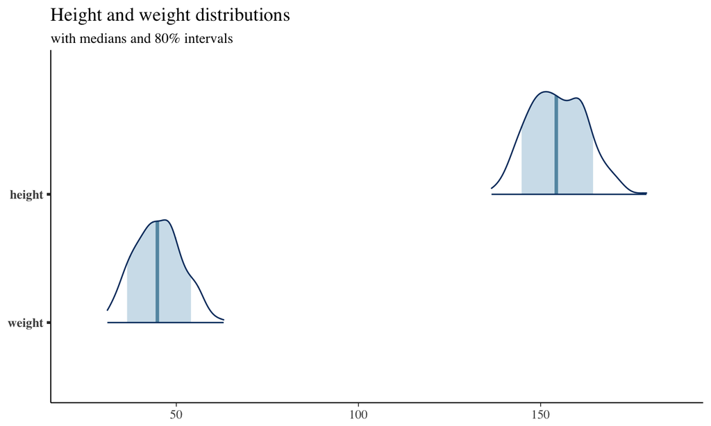

## Resources

- http://mc-stan.org > Users > Documentation > Stan Manual (pdf)
- We think adult heights are normally distributed, \(y \sim \mathcal{N}(\mu, \sigma)\)

```
data {
  int num_people;
  real heights[num_people];
}
```

```
parameters { ??? }
model { ??? }
```

## A first draft

```
data {
  int num_people;
  real heights[num_people];
}
parameters {
  real height_location;
  real<lower=0> height_scale;
}
model {
  heights ~ normal(height_location, height_scale);
  height_location ~ normal(183, 120);
  height_scale ~ normal(0, 20);
}
```

- Priors

## The fit

```
Inference for Stan model: heights1.
4 chains, each with iter=2000; warmup=1000; thin=1;
post-warmup draws per chain=1000, total post-warmup draws=4000.

                   mean se_mean   sd    2.5%     50%   97.5% n_eff Rhat
height_location  154.59    0.01 0.42  153.78  154.59  155.41  2963    1
height_scale       7.77    0.01 0.30    7.22    7.76    8.36  3184    1
lp__            -895.01    0.02 1.00 -897.71 -894.71 -894.02  1816    1

Samples were drawn using NUTS(diag_e) at Sun Dec  3 16:29:08 2017.
For each parameter, n_eff is a crude measure of effective sample size,
and Rhat is the potential scale reduction factor on split chains (at
convergence, Rhat=1).
```

## How far off are we, roughly?

- Pretend we got point estimates - take the mean of the samples of the parameter
- Use alpha as our prediction, \(\hat{y_i} = \alpha\)
- Sum the residuals/error between the true values and the "prediction"

```r
samples.simple = extract(fit1)
alpha.simple = mean(samples.simple$height_location)
sum(abs(height_data$height - alpha.simple))
```

```
[1] 2259.391
```

## Let's see if we can get a better fit

We'll look at better ways of evaluating this later, but for now we'll try to reduce the standard deviation for height by introducing weight as a predictive feature and adding a regression coefficient for it.

```
data {
  int num_people;
  vector[num_people] weights;
  real heights[num_people];
}
```

## Weight regression model

```
transformed data {
  vector[num_people] std_weights =
      (weights - mean(weights)) / sd(weights);
}
parameters {
  real height_location_avg_weight;
  real weight_coeff;
  real<lower=0> height_scale;
}
model {
  heights ~ normal(height_location_avg_weight + weight_coeff * weights
                   , height_scale);
  height_location_avg_weight ~ normal(183, 120);
  height_scale ~ normal(0, 20);
  weight_coeff ~ normal(7, 10);
}
```

## Weight regression fit

```
Inference for Stan model: heights2.
4 chains, each with iter=2000; warmup=1000; thin=1;
post-warmup draws per chain=1000, total post-warmup draws=4000.

                              mean se_mean   sd    2.5%   97.5% n_eff Rhat
height_location_avg_weight  113.92    0.05 1.96  110.16  117.76  1337    1
weight_coeff                  0.90    0.00 0.04    0.82    0.99  1330    1
height_scale                  5.10    0.00 0.20    4.70    5.52  1767    1
lp__                       -747.85    0.04 1.24 -751.15 -746.42  1180    1

Samples were drawn using NUTS(diag_e) at Sun Dec  3 16:14:46 2017.
For each parameter, n_eff is a crude measure of effective sample size,
and Rhat is the potential scale reduction factor on split chains (at
convergence, Rhat=1).
```

## How are we doing?

```r
sum(abs(height_data$height - alpha.simple))
```

```
[1] 2259.391
```

Now incorporate `weight_coeff` to get \(\hat{y_i} = \beta x_i + \alpha\)

```r
samples = extract(fit2)
alpha = mean(samples$height_location_avg_weight)
beta = mean(samples$weight_coeff)
sum(abs(height_data$height - (beta * height_data$weight + alpha)))
```

```
[1] 1390.227
```

## Interpretation

- height_location_avg_weight
- weight_coeff

```r
sd(height_data$weight) #kg
```

```
[1] 6.456708
```

## Futher directions?

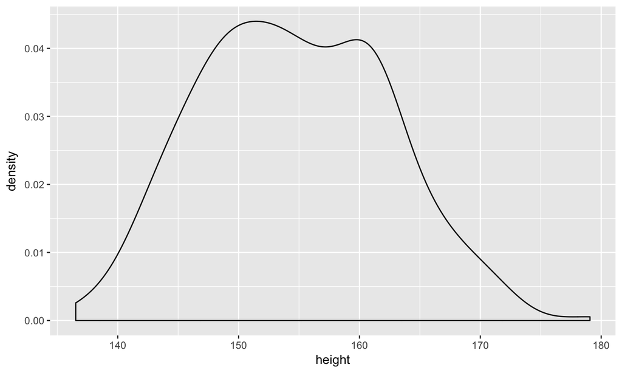